# Ben Fox’s Data 180 Final

Benjamin J. Fox

foxbe@dickinson.edu

2023-12-09

#Part One: Data Wrangling #a. What is the dimension (shape) of the dataset? How many rows and columns does the data set have?

```r
#Import loan_default_data_set.csv
bank_dataset <- read.csv("/Users/benjaminfox/Desktop/Data-180-Ben-Fox/loan_default_data_set.csv")

#Read in the dimensions of the imported data
dim(bank_dataset)
```

```
## [1] 20000    21
```

```r
#That just told me that the data set has 20000 rows a.k.a. objects, and there are 21 columns a.k.a. variables.
```

#b. Report the column names of the dataset.

```r
#Use ls to return the column names of the dataset
ls(bank_dataset)
```

```
##  [1] "avg_bal_cards"                   "credit_age"
##  [3] "credit_age_good_account"         "credit_card_age"
##  [5] "Def_ind"                         "ind_XYZ"
##  [7] "num_acc_30d_past_due_12_months"  "num_acc_30d_past_due_6_months"
##  [9] "num_auto_.36_month"              "num_card_12_month"
## [11] "num_card_inq_24_month"           "num_inq_12_month"
## [13] "num_mortgage_currently_past_due" "pct_card_over_50_uti"
## [15] "pct_over_50_uti"                 "rep_education"
## [17] "rep_income"                      "tot_amount_currently_past_due"
## [19] "tot_balance"                     "uti_max_credit_line"
## [21] "uti_open_card"
```

```r
#I'm just gonna let you read the output of ls, because all of the column names are right there.
```

#c. Which types of data are there in the dataset? Numeric, categorical, ordinal?

```r
#Use str on the data set to very quickly look at the data and the types of data in each variable.
str(bank_dataset)
```

```
## 'data.frame':    20000 obs. of  21 variables:
##  $ tot_balance                    : num  102956 132759 124659 133969 143602 ...
##  $ avg_bal_cards                  : num  14819 18952 15348 14051 14859 ...
##  $ credit_age                     : int  238 384 277 375 374 250 249 252 263 328 ...
##  $ credit_age_good_account        : int  104 197 110 224 155 178 132 139 102 169 ...
##  $ credit_card_age                : int  264 371 288 343 278 255 251 269 269 328 ...
##  $ num_acc_30d_past_due_12_months : int  0 0 0 0 0 1 0 0 0 0 ...
##  $ num_acc_30d_past_due_6_months  : int  0 0 0 0 0 0 0 0 0 0 ...
##  $ num_mortgage_currently_past_due: int  0 0 0 0 0 0 0 0 0 0 ...
##  $ tot_amount_currently_past_due  : num  0 0 0 0 0 0 0 0 0 0 ...
##  $ num_inq_12_month               : int  0 0 0 2 0 0 0 0 0 0 ...
##  $ num_card_inq_24_month          : int  0 0 0 2 0 1 0 0 0 0 ...
##  $ num_card_12_month              : int  1 0 0 1 0 0 0 0 0 0 ...
##  $ num_auto_.36_month             : int  0 0 0 0 0 0 0 0 1 0 ...
##  $ uti_open_card                  : num  0.367 0.491 0.359 0.7 0.647 ...
##  $ pct_over_50_uti                : num  0.342 0.541 0.339 0.684 0.511 ...
##  $ uti_max_credit_line            : num  0.514 0.418 0.342 0.543 0.633 ...
##  $ pct_card_over_50_uti           : num  0.551 NA 0.451 0.608 0.574 ...
##  $ ind_XYZ                        : int  0 0 0 0 0 0 0 1 0 1 ...
##  $ rep_income                     : num  118266 89365 201365 191794 161465 ...
##  $ rep_education                  : chr  "college" "college" "college" "college" ...
##  $ Def_ind                        : int  0 0 0 0 0 0 0 0 0 0 ...
```

```r
#Almost all of the data in the data set is numeric, the only exception being rep_education. That variable is a categorical variable. I am tempted to call it an ordinal variable since when analyzing I might be prompted to order that variable based on the types of education given, however since no immediate means of ordering that data exists, it will be presumed to be categorical.
```

#d. Which columns contain missing values and how much (what percent) of those columns are missing?

```r
#Create a blank list as long as the list that's going to need to be created
TF <- numeric(length(colnames(bank_dataset)))

#Create a for loop to sort through every column of the data set
for (i in 1:ncol(bank_dataset)){
    #How many missing values are in this column
    missing_values <- sum(is.na(bank_dataset[,i]))

    #What percent of the column is that
    missing_values_percent <- (missing_values / 20000) * 100

    #Put that percentage into the list
    TF[i] <- missing_values_percent
}

#Print that list
TF
```

```
##  [1] 0.000 0.000 0.000 0.000 0.000 0.000 0.000 0.000 0.000 0.000 0.000 0.000
## [13] 0.000 0.000 0.000 0.000 9.790 0.000 7.795 0.000 0.000
```

#e. How do you think we should deal with missing values? There are a multitude of ways to deal with missing values. One way is to simply set every missing value to zero, and use that as they come up. Problems there include skewing the data in a completely wrong direction, so we could try to counter balance this by setting all missing values to the mean. This could cause problems if the data is very scattered with little sense of direction, forcing a mode and story where none exist. We could try to generally scatter all missing values along the range correlating to their likelihood to be anywhere, which might sound good but would likely mess with any sort of unsupervised learning if it has no way to know what value it’d most likely be in a given object. We could also simply remove values from the data set, which I would find to be the most practical in getting the most complete data possible, but still, missing values show up all the time, and if too many values are taken from the data set it becomes completely unusable. We could try to remove all missing values depending on when we do or don’t need them, but we never really know when that exactly is so it’s a very flawed approach. I’m not sure what to do.

#f. With this data, would you fit a supervised or an unsupervised learning model? Why? I would go with an unsupervised learning model to attempt to sort all of the objects into clusters to try to figure out a possible way to treat the data coming in and begin to understand what’s likely to happen when or if new data is added to the set.

#g. For part 2 and 3 drop all rows of the data that contain missing values. Print the dimensions of the resulting dataset that has no missing values.

```r
#Creates an empty data frame
complete_bank_dataset <- data.frame()

#Create a for loop to sort through every object
for (i in 1:nrow(bank_dataset)){
  #Set truth variable so that we can account for objects with missing values
  truth <- 1
  #Sort through every column of that object
  for (j in 1:ncol(bank_dataset)){
    #Check to see if any of those columns contain a missing value
    if (isTRUE(is.na(bank_dataset[i,j]))){
      #If it does, set that previous truth value to zero
      truth <- 0
    }
  }
  #Check to see if that previous truth value accessed still exists
  if (truth == 1){
    #If it does, then the entire object exists, and I'll put that object into the new dataset
    complete_bank_dataset <- rbind(complete_bank_dataset, bank_dataset[i,])
  }
}

#Rename each row to be their new proper number
row.names(complete_bank_dataset) <- 1:nrow(complete_bank_dataset)

#Read the head of the new data set to make sure everything worked properly
head(complete_bank_dataset)
```

```
##   tot_balance avg_bal_cards credit_age credit_age_good_account credit_card_age
## 1    102956.1      14819.06        238                     104             264
## 2    124658.9      15347.93        277                     110             288
## 3    133968.5      14050.71        375                     224             343
## 4    143601.8      14858.52        374                     155             278
## 5    154508.5      19626.36        249                     132             251
## 6    121591.0      11143.19        252                     139             269
##   num_acc_30d_past_due_12_months num_acc_30d_past_due_6_months
## 1                              0                             0
## 2                              0                             0
## 3                              0                             0
## 4                              0                             0
## 5                              0                             0
## 6                              0                             0
##   num_mortgage_currently_past_due tot_amount_currently_past_due
```

[output cut: 27 more lines]

```r
#Get the dimensions of the dataset, which I can see in the environment is 16653 x 21
dim(complete_bank_dataset)
```

```
## [1] 16653    21
```

#Part Two: Data Summary Statistics: #a. Find the summary statistics of the data set. You can use the summary function from dplyr.

```r
#Import dplyr library
library("dplyr")
#Summarize the dataset
summary(complete_bank_dataset)
```

```
##   tot_balance     avg_bal_cards     credit_age    credit_age_good_account
##  Min.   :     0   Min.   :    0   Min.   :  0.0   Min.   :  0.0
##  1st Qu.: 92142   1st Qu.:10135   1st Qu.:231.0   1st Qu.:120.0
##  Median :107740   Median :12237   Median :281.0   Median :146.0
##  Mean   :107503   Mean   :12226   Mean   :280.9   Mean   :146.2
##  3rd Qu.:122932   3rd Qu.:14297   3rd Qu.:330.0   3rd Qu.:172.0
##  Max.   :200000   Max.   :25000   Max.   :550.0   Max.   :300.0
##  credit_card_age num_acc_30d_past_due_12_months num_acc_30d_past_due_6_months
##  Min.   :  0.0   Min.   :0.0000                 Min.   :0.00000
##  1st Qu.:242.0   1st Qu.:0.0000                 1st Qu.:0.00000
##  Median :285.0   Median :0.0000                 Median :0.00000
##  Mean   :285.4   Mean   :0.1579                 Mean   :0.02936
##  3rd Qu.:330.0   3rd Qu.:0.0000                 3rd Qu.:0.00000
##  Max.   :550.0   Max.   :5.0000                 Max.   :2.00000
##  num_mortgage_currently_past_due tot_amount_currently_past_due
##  Min.   :0.0000                  Min.   :    0.0
##  1st Qu.:0.0000                  1st Qu.:    0.0
##  Median :0.0000                  Median :    0.0
##  Mean   :0.0299                  Mean   :  354.2
##  3rd Qu.:0.0000                  3rd Qu.:    0.0
##  Max.   :1.0000                  Max.   :35000.0
##  num_inq_12_month  num_card_inq_24_month num_card_12_month num_auto_.36_month
##  Min.   : 0.0000   Min.   : 0.000        Min.   :0.0000    Min.   :0.000
##  1st Qu.: 0.0000   1st Qu.: 0.000        1st Qu.:0.0000    1st Qu.:0.000
##  Median : 0.0000   Median : 0.000        Median :0.0000    Median :0.000
##  Mean   : 0.6133   Mean   : 1.044        Mean   :0.2723    Mean   :0.165
##  3rd Qu.: 1.0000   3rd Qu.: 1.000        3rd Qu.:1.0000    3rd Qu.:0.000
##  Max.   :10.0000   Max.   :18.000        Max.   :3.0000    Max.   :2.000
##  uti_open_card    pct_over_50_uti  uti_max_credit_line pct_card_over_50_uti
##  Min.   :0.0000   Min.   :0.0000   Min.   :0.0000      Min.   :0.0000
##  1st Qu.:0.4048   1st Qu.:0.4011   1st Qu.:0.3778      1st Qu.:0.4643
##  Median :0.4909   Median :0.4855   Median :0.4649      Median :0.5518
##  Mean   :0.4914   Mean   :0.4842   Mean   :0.4653      Mean   :0.5511
##  3rd Qu.:0.5783   3rd Qu.:0.5679   3rd Qu.:0.5541      3rd Qu.:0.6384
##  Max.   :1.0000   Max.   :0.9294   Max.   :1.0000      Max.   :1.0000
##     ind_XYZ         rep_income     rep_education         Def_ind
##  Min.   :0.0000   Min.   : 20000   Length:16653       Min.   :0.0000
##  1st Qu.:0.0000   1st Qu.:143751   Class :character   1st Qu.:0.0000
##  Median :0.0000   Median :166630   Mode  :character   Median :0.0000
##  Mean   :0.2487   Mean   :166504                      Mean   :0.1019
##  3rd Qu.:0.0000   3rd Qu.:189020                      3rd Qu.:0.0000
##  Max.   :1.0000   Max.   :300000                      Max.   :1.0000
```

#b. Based on the mean, mode, and median, is “num_card_inq_24_month” bell shaped, left, right skewed? How about “tot_amount_currently_past_due”? “credit_age”?

```r
#Create stat_mode function so that you can find the mode of any variable asked for without too much difficulty
stat_mode <- function(x){
  #Creates a variable that gets all values in the variable, just eliminating duplicates
  unique_synonym <- unique(x)

  #Take that variable, match up all of the cases in which a unique value, tally up the amount of times they occur, and figure out which one of those is the largest and returns that value.
  unique_synonym[which.max(tabulate(match(x, unique_synonym)))]
}

#Get the mean, median, and create a function to find the mode of "num_card_inq_24_month"
mean(complete_bank_dataset$num_card_inq_24_month) #1.043896
```

```
## [1] 1.043896
```

```r
median(complete_bank_dataset$num_card_inq_24_month) #0
```

```
## [1] 0
```

```r
stat_mode(complete_bank_dataset$num_card_inq_24_month) #0
```

```
## [1] 0
```

```r
#This data is likely somewhat skewed right, as a vast majority of the data is at the lower value, but some higher values are giving the data a slight tail right.

#Get the mean, median, and mode of "tot_amount_currently_past_due"
mean(complete_bank_dataset$tot_amount_currently_past_due) #354.1857
```

```
## [1] 354.1857
```

```r
median(complete_bank_dataset$tot_amount_currently_past_due) #0
```

```
## [1] 0
```

```r
stat_mode(complete_bank_dataset$tot_amount_currently_past_due) #0
```

```
## [1] 0
```

```r
#The data is heavily skewed right, with the mean being much higher than the mean or mode due to some very high values pulling the mean very far from the 0 that is much more common

#Get the mean, median, and mode of "credit_age"
mean(complete_bank_dataset$credit_age) #280.8684
```

```
## [1] 280.8684
```

```r
median(complete_bank_dataset$credit_age) #281
```

```
## [1] 281
```

```r
stat_mode(complete_bank_dataset$credit_age) #295
```

```
## [1] 295
```

```r
#The data is likely somewhat skewed left, but is mostly a bell curve, the mean is pulled by the lower values, and the median is too, albeit to a lower degree, but more commonly seen are values that are greater than both the mean and median.
```

#c. Plot a histogram of the variables in b above. Do the shapes of the histograms confirm the skewness you found in b?

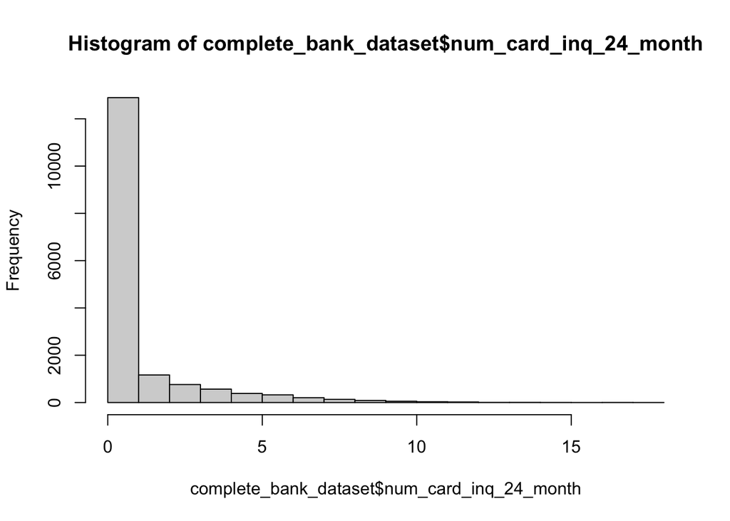

```r
#Create a basic histogram for "num_card_inq_24_month"
hist(complete_bank_dataset$num_card_inq_24_month)
```

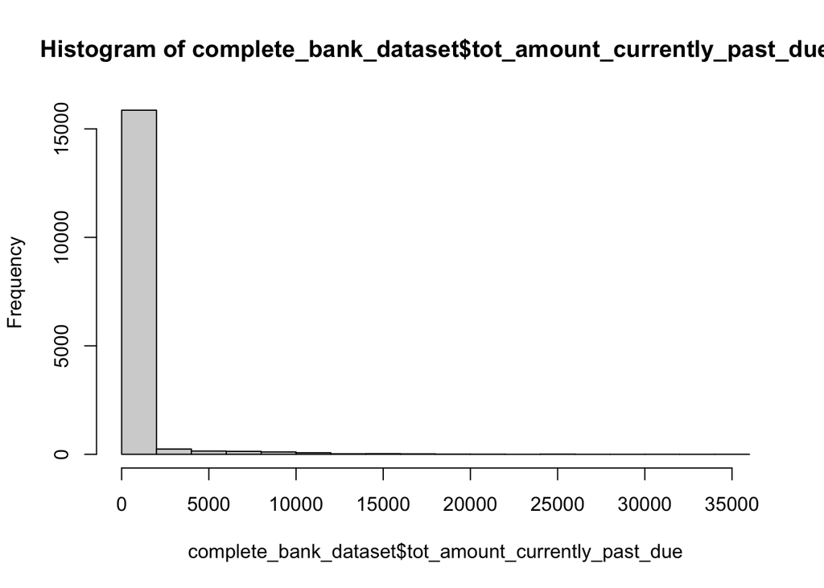

```r
#The data is far more skewed right than I thought, simply because I didn't realize the mean being pulled slightly in a direction could still imply far more existing.

#Create a basic histogram for "tot_amount_currently_past_due"
hist(complete_bank_dataset$tot_amount_currently_past_due)
```

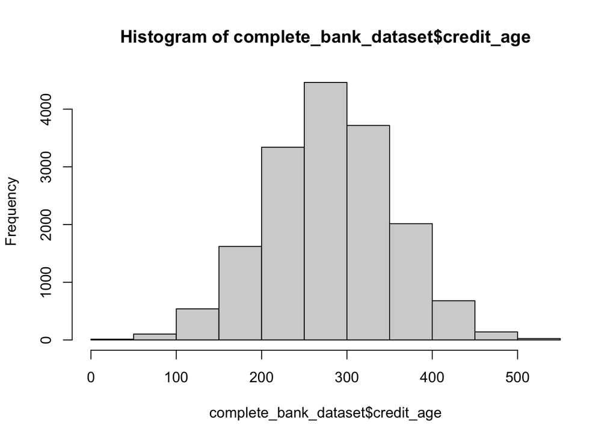

```r
#This is near exactly as I expected, albeit more mode-centric than I thought, as the mode bin here has over 15000 objects, while the previous histogram contained  a bit over 10000

#Create a basic histogram for "credit_age"
hist(complete_bank_dataset$credit_age)
```

```r
#Again, this is around what I expected, maybe a bit more of a bell curve than I thought, though it is nice to see a proper bell curve in the face of those two curves being so skewed right.
```

#d. How would you convert the “rep_education” column into numerical data? Name two ways. The immediate way I think to convert rep_education into numerical data is to directly turn each category into a number from 0-3, 0 for other, then progressively climbing up stages of education until 3 is graduate. Or, and this is a weirder way, but you could find every time one of the categories in “rep_education” occurs, tally those up, and then reassign those categories in the “rep_education” column to the numbers that correspond to their frequency.

#Part Three: Data Visualization. For every graph in this section, remember to label your axes and to include a title. feel free to play around with graphics and parameters. Have fun and explore! #a. Plot a bar graph for the “Def_Ind” column and describe it.

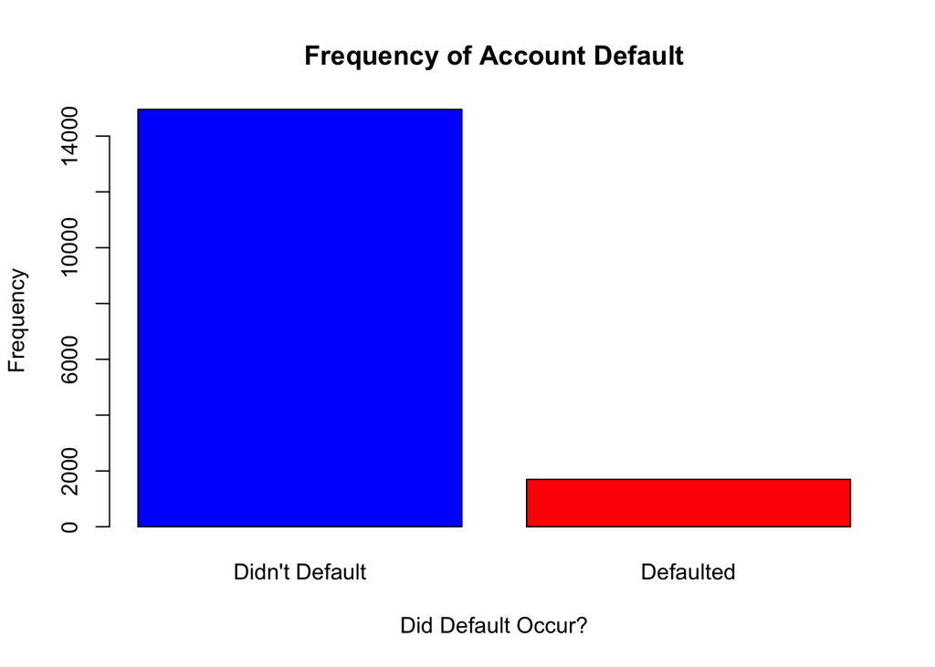

```r
#Creating an independent variable to store "Def_Ind" column data
defaulted <- complete_bank_dataset$Def_ind

#Creating another variable to calculate the frequency of defaults
default_frequency <- table(defaulted)

#Renaming the columns in the newly created table
names(default_frequency) <- c("Didn't Default", "Defaulted")

#Creating a bar plot with that data
barplot(default_frequency,
        main = "Frequency of Account Default",
        xlab = "Did Default Occur?",
        ylab = "Frequency",
        col = c("blue","red"))
```